# Разработка модели вероятности дефолта

В данной рабочей тетради описан процесс разработки скоринговой карты

```r
#install.packages("scorecard")
library(ggplot2)
library(corrplot)
library(MASS)
library(caTools)
library(data.table)
library(Matrix)
library(xgboost)
library(party)
library(ggthemes)
library(ggmosaic)
library(InformationValue)
library(Information)
library(ClustOfVar)
library(MLmetrics)
#library(sparklyr)
library(dplyr)
library(ROCR)
library(scorecard)
library(ggpubr)
```

## Данные разработки

### Загрузка данных

Набор данных для разработки модели находится в CSV-файле

```r
abt <- as.data.frame(read.csv("abt_default3.csv", header=TRUE, sep="\t"))
head(abt)
```

|  | Var1 | Var2 | Var3 | Var4 | Var5 | Var6 | Var7 | Var8 | Var9 | Var10 | Var11 | Var12 | Var13 | Var14 | Var15 | Var16 | Var17 | Var18 | Var19 | Var20 | Var21 | Var22 | Var23 | Var24 | Var25 | Var26 | Var27 | Var28 | Var29 | … |
| --- | --- | --- | --- | --- | --- | --- | --- | --- | --- | --- | --- | --- | --- | --- | --- | --- | --- | --- | --- | --- | --- | --- | --- | --- | --- | --- | --- | --- | --- | --- |
| 1 | NA | NA | NA | NA | NA | 1526 | 7 | NA | NA | NA | NA | NA | 184 | NA | NA | NA | NA | NA | NA | NA | 464 | 580 | NA | 14 | 128 | NA | NA | 166.56 | NA | … |
| 2 | NA | NA | NA | NA | NA | 525 | 0 | NA | NA | NA | NA | NA | 0 | NA | NA | NA | NA | NA | NA | NA | 168 | 210 | NA | 2 | 24 | NA | NA | 353.52 | NA | … |
| 3 | NA | NA | NA | NA | NA | 5236 | 7 | NA | NA | NA | NA | NA | 904 | NA | NA | NA | NA | NA | NA | NA | 1212 | 1515 | NA | 26 | 816 | NA | NA | 220.08 | NA | … |
| 4 | NA | NA | NA | NA | NA | NA | 0 | NA | NA | NA | NA | NA | 0 | NA | NA | NA | NA | NA | NA | NA | NA | 0 | NA | NA | 0 | NA | NA | 22.08 | NA | … |
| 5 | NA | NA | NA | NA | NA | 1029 | 7 | NA | NA | NA | NA | NA | 3216 | NA | NA | NA | NA | NA | NA | NA | 64 | 80 | NA | 4 | 64 | NA | NA | 200.00 | NA | … |
| 6 | NA | NA | NA | NA | NA | 658 | 7 | NA | NA | NA | NA | NA | 3156 | NA | NA | NA | NA | NA | NA | NA | 224 | 280 | NA | 2 | 72 | NA | NA | 200.00 | NA | … |

### Первичный анализ и преобразование данных

Количество наблюдений

```r
abt <- abt %>% mutate(REPORT_DT = as.Date(REPORT_DT))
abt %>% dplyr::group_by(REPORT_DT) %>%
                dplyr::summarise(cnt = n())
```

| REPORT_DT | cnt |
| --- | --- |
| 2016-11-30 | 10026 |
| 2016-12-31 | 9898 |
| 2017-01-31 | 9956 |
| 2017-02-28 | 10140 |
| 2017-03-31 | 9980 |

Значения целевой переменной

```r
as.data.frame(unique(abt$default_flg))
```

| unique(abt$default_flg) |
| --- |
| -1 |
| 1 |

Замена значений целевой переменной $-1$ на $0$

```r
abt$default_flg[abt$default_flg == -1]<-0
as.data.frame(unique(abt$default_flg))
```

| unique(abt$default_flg) |
| --- |
| 0 |
| 1 |

#### Список переменных в наборе данных

```r
abt_meta <- as.data.frame(colnames(abt))
colnames(abt_meta) <- "Variable"
abt_meta$Variable <- as.character(abt_meta$Variable)
abt_meta$Description <- paste("Переменная ", abt_meta$Variable)
abt_meta$Role <- NA
```

Типы данных переменных

```r
abt$REPORT_DT <- as.Date(abt$REPORT_DT)
abt_meta$Type <- sapply(abt, class)
abt_meta$Role[abt_meta$Variable=="default_flg"] <- "Target"
abt_meta$Role[abt_meta$Variable=="REPORT_DT"] <- "Drop"
#head(abt)
abt_meta$Type <- ifelse(abt_meta$Type == "integer" | abt_meta$Type == "numeric","interval",abt_meta$Type)
abt_meta$Type <- ifelse(abt_meta$Type == "factor","character",abt_meta$Type)
logicals = abt_meta %>% filter(Type == "logical") %>% dplyr::select(Variable)
for(i in logicals$Variable){
  abt[[i]] <- as.integer(abt[[i]])
}
abt_meta$Type <- ifelse(abt_meta$Type == "logical","interval",abt_meta$Type)
abt_meta %>% group_by(Type) %>% summarise(cnt=n())
```

| Type | cnt |
| --- | --- |
| character | 38 |
| Date | 1 |
| interval | 193 |

Переменные

```r
abt_meta
```

| Variable | Description | Role | Type |
| --- | --- | --- | --- |
| Var1 | Переменная Var1 | NA | interval |
| Var2 | Переменная Var2 | NA | interval |
| Var3 | Переменная Var3 | NA | interval |
| Var4 | Переменная Var4 | NA | interval |
| Var5 | Переменная Var5 | NA | interval |
| Var6 | Переменная Var6 | NA | interval |
| Var7 | Переменная Var7 | NA | interval |
| Var8 | Переменная Var8 | NA | interval |
| Var9 | Переменная Var9 | NA | interval |
| Var10 | Переменная Var10 | NA | interval |

[output cut: 222 more lines]

### Обработка пропущенных значений

Количество переменных с пропущенными значениями

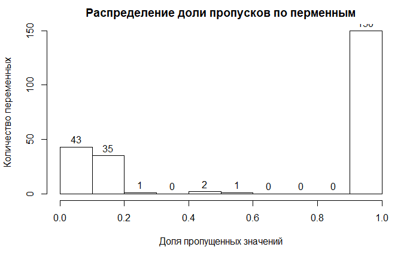

```r
abt_meta$na <- sapply(X = abt, FUN = function(x){sum(is.na(x))/nrow(abt)})
hist(abt_meta$na,
     main = "Распределение доли пропусков по перменным",
     xlab = "Доля пропущенных значений",
     ylab = "Количество переменных",
     labels = TRUE)
```

Исключение переменных с долей пропусков $> 20\%$

```r
abt_meta$Role <- ifelse((abt_meta$na>0.2)==TRUE,"Drop",abt_meta$Role)
abt_meta$Role <- ifelse(is.na(abt_meta$Role),"Input",abt_meta$Role)
```

Переменные после исключения

```r
abt_meta %>% filter(Role == "Input") %>% group_by(Type) %>% summarise(cnt=n())
```

| Type | cnt |
| --- | --- |
| character | 38 |
| interval | 38 |

```r
abt_meta %>% filter(Role == "Input")
```

| Variable | Description | Role | Type | na |
| --- | --- | --- | --- | --- |
| Var6 | Переменная Var6 | Input | interval | 0.11058 |
| Var7 | Переменная Var7 | Input | interval | 0.11078 |
| Var13 | Переменная Var13 | Input | interval | 0.11078 |
| Var21 | Переменная Var21 | Input | interval | 0.11058 |
| Var22 | Переменная Var22 | Input | interval | 0.10018 |
| Var24 | Переменная Var24 | Input | interval | 0.14460 |
| Var25 | Переменная Var25 | Input | interval | 0.10018 |
| Var28 | Переменная Var28 | Input | interval | 0.10022 |
| Var35 | Переменная Var35 | Input | interval | 0.10018 |
| Var38 | Переменная Var38 | Input | interval | 0.10018 |

[output cut: 66 more lines]

Замена пропущенных значений интервальных переменных на 0

```r
impute_med <- function(x){ifelse(is.na(x), median(x, na.rm = TRUE), x)}
impute_zero <- function(x){ifelse(is.na(x), 0, x)}
numerics = abt_meta %>% filter(Type == "interval" & Role == "Input") %>% dplyr::select(Variable)
for(i in numerics$Variable){
  abt[[i]][is.na(abt[[i]])] <- 0
}
```

Замена пропущенных значений номинальных переменных на “UNKNOWN”

```r
factors = abt_meta %>% filter(Type == "character" & Role == "Input") %>% dplyr::select(Variable)
for(i in factors$Variable){
  #abt[[i]][is.na(abt[[i]])] <- "UNKNOWN"
  abt[[i]] <- as.character(abt[[i]])
}
for(i in factors$Variable){
  abt[[i]][(abt[[i]])==""] <- "UNKNOWN"
}
inputs = (abt_meta %>% filter(Role == "Input"))$Variable
head(abt[,as.character(inputs)])
```

|  | Var6 | Var7 | Var13 | Var21 | Var22 | Var24 | Var25 | Var28 | Var35 | Var38 | Var44 | Var57 | Var65 | Var73 | Var74 | Var76 | Var78 | Var81 | Var83 | Var85 | Var109 | Var112 | Var113 | Var119 | Var123 | Var125 | Var132 | Var133 | Var134 | … |
| --- | --- | --- | --- | --- | --- | --- | --- | --- | --- | --- | --- | --- | --- | --- | --- | --- | --- | --- | --- | --- | --- | --- | --- | --- | --- | --- | --- | --- | --- | --- |
| 1 | 1526 | 7 | 184 | 464 | 580 | 14 | 128 | 166.56 | 0 | 3570 | 0 | 4.0769070 | 9 | 36 | 35 | 1350864 | 0 | 7333.11 | 5 | 12 | 104 | 168 | 117625.60 | 1175 | 6 | 720 | 0 | 1212385 | 69134 | … |
| 2 | 525 | 0 | 0 | 168 | 210 | 2 | 24 | 353.52 | 0 | 4764966 | 0 | 5.4080320 | 9 | 26 | 0 | 2872928 | 3 | 151098.90 | 25 | 2 | 40 | 40 | -356411.60 | 590 | 72 | 0 | 8 | 4136430 | 357038 | … |
| 3 | 5236 | 7 | 904 | 1212 | 1515 | 26 | 816 | 220.08 | 0 | 5883894 | 0 | 6.5996580 | 9 | 130 | 518 | 1675776 | 0 | 16211.58 | 40 | 58 | 312 | 336 | 405104.00 | 3230 | 114 | 5967 | 0 | 3478905 | 248932 | … |
| 4 | 0 | 0 | 0 | 0 | 0 | 0 | 0 | 22.08 | 0 | 0 | 0 | 1.9882500 | 9 | 12 | 0 | 0 | 0 | 0.00 | 0 | 0 | 0 | 0 | -275703.60 | 0 | 0 | 0 | 0 | 0 | 0 | … |
| 5 | 1029 | 7 | 3216 | 64 | 80 | 4 | 64 | 200.00 | 0 | 0 | 0 | 4.5524460 | 18 | 82 | 224 | 784448 | 0 | 37423.50 | 0 | 0 | 32 | 56 | 10714.84 | 215 | 0 | 15111 | 0 | 150650 | 66046 | … |
| 6 | 658 | 7 | 3156 | 224 | 280 | 2 | 72 | 200.00 | 5 | 0 | 0 | 0.1664174 | 9 | 126 | 196 | 209048 | 0 | 11370.72 | 0 | 10 | 32 | 64 | 369814.00 | 755 | 0 | 1935 | 8 | 641020 | 43684 | … |

```r
factors = as.character((abt_meta %>% filter(Type == "character" & Role == "Input")) $Variable)
```

### Исключение номинальных факторов с большим числом уровней

Количество уровней по номинальным факторам

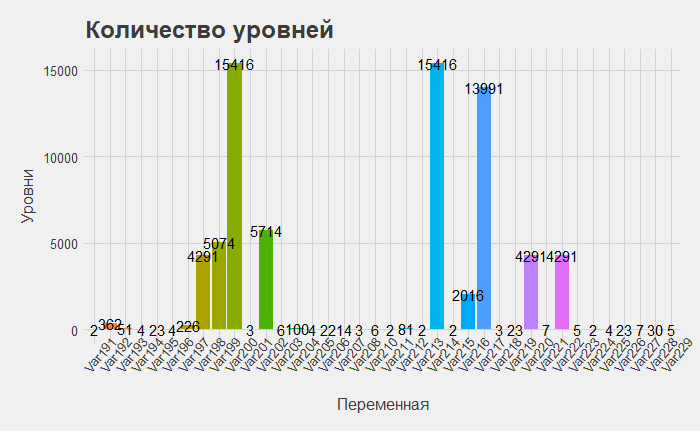

```r
factors = abt_meta %>% filter(Type == "character") %>% dplyr::select(Variable)
for(i in factors$Variable){
  abt[[i]] <- as.factor(abt[[i]])
}
abt_meta$NLevels = sapply(abt,nlevels)
ggplot(data = (abt_meta %>% filter(Type == "character" & Role == "Input")),
       aes(x = Variable, y = NLevels, fill = Variable)) +
  geom_bar(stat = "identity") +
  geom_text(aes(label=NLevels)) +
  xlab("Переменная") +
  ylab("Уровни") +
  ggtitle("Количество уровней") +
  theme_fivethirtyeight() +
  theme(legend.position = "none", axis.title=element_text(size=12),
        axis.text.x = element_text(angle = 50))
```

Исключение переменных с числом уровней $>50$

```r
abt_meta$Role <- ifelse((abt_meta$NLevels>50)==TRUE,"Drop",abt_meta$Role)
```

#### Список отобранных переменных

```r
factors = as.character((abt_meta %>% filter(Type == "character" & Role == "Input")) $Variable)
numerics = as.character((abt_meta %>% filter(Type == "interval" & Role == "Input")) $Variable)
inputs = c(numerics,factors)
#inputs
abt_meta %>% filter(Type %in% c("character", "interval") & Role == "Input")
```

| Variable | Description | Role | Type | na | NLevels |
| --- | --- | --- | --- | --- | --- |
| Var6 | Переменная Var6 | Input | interval | 0.11058 | 0 |
| Var7 | Переменная Var7 | Input | interval | 0.11078 | 0 |
| Var13 | Переменная Var13 | Input | interval | 0.11078 | 0 |
| Var21 | Переменная Var21 | Input | interval | 0.11058 | 0 |
| Var22 | Переменная Var22 | Input | interval | 0.10018 | 0 |
| Var24 | Переменная Var24 | Input | interval | 0.14460 | 0 |
| Var25 | Переменная Var25 | Input | interval | 0.10018 | 0 |
| Var28 | Переменная Var28 | Input | interval | 0.10022 | 0 |
| Var35 | Переменная Var35 | Input | interval | 0.10018 | 0 |
| Var38 | Переменная Var38 | Input | interval | 0.10018 | 0 |

[output cut: 52 more lines]

### Уровень дефолта

Доля событий дефолта

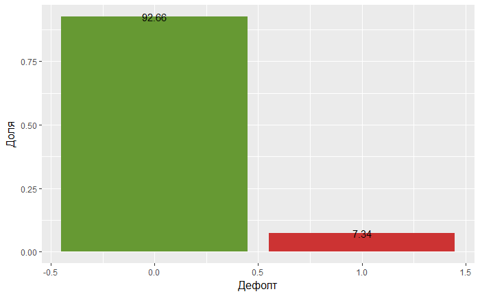

```r
ggplot(aes(x = default_flg),
       data = abt) +
  geom_bar(aes(y = ..count../ sum(..count..)),
           stat = "count",
           fill = c("#669933","#CC3333"),
           size = 1.5) +
  xlab('Дефолт') +
  ylab('Доля') +
  theme(axis.title=element_text(size=12),
        legend.title = element_blank()) +
  geom_text(aes(label = round((..count../ sum(..count..))*100,2),
                y= ..prop..),
            stat = "count")
```

Доля дефолта в разрезе переменной Var196

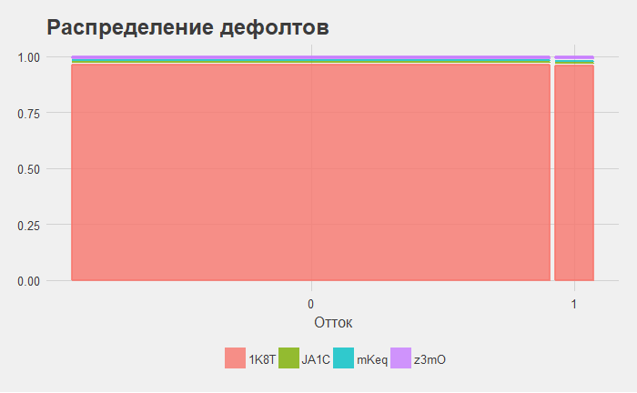

```r
ggplot(data = abt) +
  geom_mosaic(aes(x = product(default_flg), fill = Var196),  size = 1) +
  ggtitle("Распределение дефолтов") +
  theme_fivethirtyeight() +
  xlab('Отток') +
  theme(axis.title=element_text(size=12),
        legend.title = element_blank())
```

График концентрации наблюдений по переменной Var196

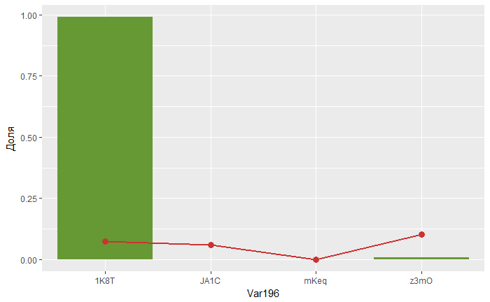

```r
ggplot(abt, aes(x=Var196, group=1)) +
  geom_bar(aes(y = ..count../ sum(..count..)),
           position = "dodge",
           stat="count",
           fill = "#669933")+
  geom_point(aes(y = default_flg),
             stat="summary",
             fun.y = "mean",
             colour="#CC3333",
             size=3
  )+
  geom_line(aes(y = default_flg),
            stat="summary",
            fun.y = "mean",
            colour="#CC3333",
            size=1) +
  ylab('Доля')
```

## Разработка моделей

### Отбор факторов

Корреляционная матрица по интервальным переменным

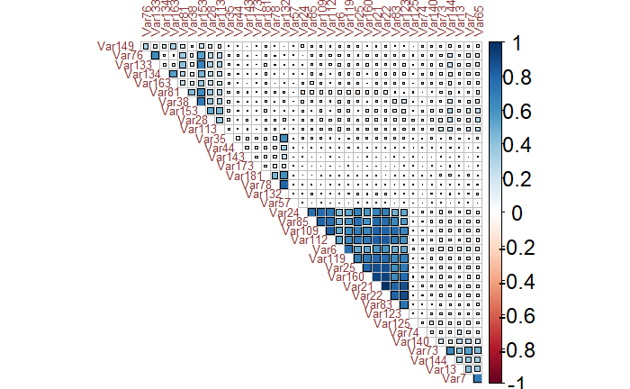

```r
m <- cor(abt[ ,numerics])
corrplot(m, type = "upper", order="hclust", method = "square", outline = T, tl.col = "indianred4", tl.cex = 0.8, cl.cex = 1.5, diag=FALSE)
```

Зависимость между переменными Var133 Var153

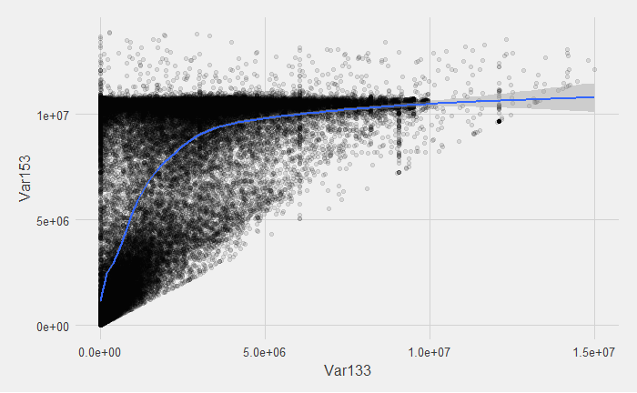

```r
#install.packages("mgcv")
ggplot(aes(x = Var133, y = Var153), data = abt) +
  geom_point(alpha = 0.1) +
  theme_fivethirtyeight() +
  theme(axis.title=element_text(size=12)) +
  stat_smooth()
```

Кластеризация переменных

Иерархическая кластеризация

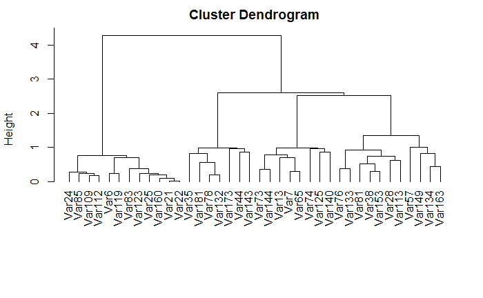

```r
clust_tree <- hclustvar(data.matrix(abt[,numerics]))
plot(clust_tree)
```

Отбор переменных по высоте в иерархии

```r
nvars <- length(clust_tree[clust_tree$height<0.7])
part_init<-cutreevar(clust_tree,nvars)$cluster
```

k-means кластеризация

```r
clust_kmeans <- kmeansvar(X.quanti=data.matrix(abt[,numerics]),init=part_init)
clusters <- cbind.data.frame(melt(clust_kmeans$cluster), row.names(melt(clust_kmeans$cluster)))
names(clusters) <- c("Cluster", "Variable")
```

Кластеры переменных

```r
clusters
```

|  | Cluster | Variable |
| --- | --- | --- |
| Var6 | 1 | Var6 |
| Var7 | 2 | Var7 |
| Var13 | 3 | Var13 |
| Var21 | 4 | Var21 |
| Var22 | 4 | Var22 |
| Var24 | 5 | Var24 |
| Var25 | 4 | Var25 |
| Var28 | 6 | Var28 |
| Var35 | 7 | Var35 |
| Var38 | 8 | Var38 |

[output cut: 28 more lines]

```r
abt_meta <- abt_meta %>% left_join(clusters, by="Variable")
```

### Разделение на обучающую и тестовую выборки

Распределение событий по отчетным датам

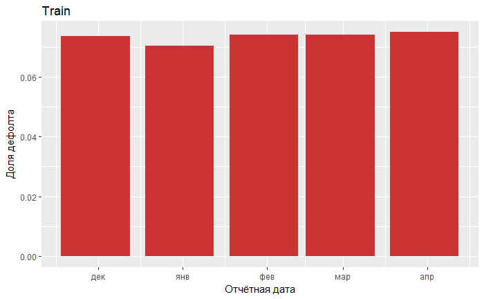

```r
ggplot(abt, aes(x=REPORT_DT)) +
  geom_bar(aes(y = default_flg),
           position = "dodge",
           stat="summary",
           fun.y = "mean",
           fill="#CC3333") +
  ggtitle("Train") +
  xlab('Отчётная дата') +
  ylab('Доля дефолта')
```

Train - REPORT_DT $\leq$ “2017-01-31”, Test - REPORT_DT $>$ “2017-01-31”

```r
abt_train <- abt %>% filter(REPORT_DT <= "2017-01-31")
abt_test <- abt %>% filter(REPORT_DT > "2017-01-31")
```

### Расчет информационных критериев

```r
abt_IVCheck <- CheckInputs(train=abt_train[,c(inputs,"default_flg")], valid=abt_test[,c(inputs,"default_flg")], trt=NULL, y="default_flg")
abt_train <- abt_IVCheck[[1]]
abt_test <- abt_IVCheck[[2]]
```

Расчет IV

```r
IV <- create_infotables(data=abt_train,
                        valid=abt_test,
                        y="default_flg",
                        parallel=FALSE)
```

IV по переменной Var7

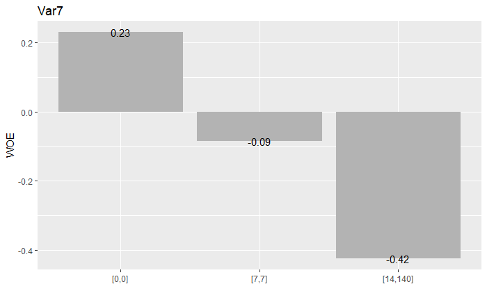

```r
plot_infotables(IV, "Var7", show_values=TRUE)
```

Добавление IV в метаданные ABT

```r
abt_meta <- abt_meta %>% left_join(IV$Summary, by="Variable")
```

Расчет индекса Gini

```r
gini <- apply(X=abt_train, MARGIN=2, FUN=function(x) abs(Gini(x, abt_train$default_flg) ))
GiniIndex = as.data.frame(names(gini))
colnames(GiniIndex) <- "Variable"
GiniIndex$GiniIndex <- gini
abt_meta <- abt_meta %>% left_join(GiniIndex, by="Variable")
```

#### Короткий список переменных

```r
abt_meta %>% filter(Role == "Input") %>% arrange(Cluster, -GiniIndex)
```

| Variable | Description | Role | Type | na | NLevels | Cluster | IV | PENALTY | AdjIV | GiniIndex |
| --- | --- | --- | --- | --- | --- | --- | --- | --- | --- | --- |
| Var6 | Переменная Var6 | Input | interval | 0.11058 | 0 | 1 | 2.518708e-02 | 0.0052585698 | 1.992851e-02 | 0.053418729 |
| Var119 | Переменная Var119 | Input | interval | 0.11058 | 0 | 1 | 1.136863e-02 | 0.0043673464 | 7.001280e-03 | 0.016775178 |
| Var7 | Переменная Var7 | Input | interval | 0.11078 | 0 | 2 | 4.877238e-02 | 0.0026235381 | 4.614885e-02 | 0.108751693 |
| Var65 | Переменная Var65 | Input | interval | 0.11078 | 0 | 2 | 4.675873e-02 | 0.0052298218 | 4.152890e-02 | 0.033485054 |
| Var13 | Переменная Var13 | Input | interval | 0.11078 | 0 | 3 | 5.361240e-02 | 0.0089371554 | 4.467524e-02 | 0.119021180 |
| Var123 | Переменная Var123 | Input | interval | 0.10018 | 0 | 4 | 1.543703e-02 | 0.0058849653 | 9.552064e-03 | 0.043095006 |
| Var83 | Переменная Var83 | Input | interval | 0.10018 | 0 | 4 | 5.996342e-03 | 0.0026607392 | 3.335602e-03 | 0.032101279 |
| Var25 | Переменная Var25 | Input | interval | 0.10018 | 0 | 4 | 7.395653e-03 | 0.0035906946 | 3.804958e-03 | 0.020234032 |
| Var160 | Переменная Var160 | Input | interval | 0.10018 | 0 | 4 | 1.240834e-02 | 0.0053270368 | 7.081306e-03 | 0.019288862 |
| Var22 | Переменная Var22 | Input | interval | 0.10018 | 0 | 4 | 8.810480e-03 | 0.0055263358 | 3.284144e-03 | 0.017726762 |

[output cut: 52 more lines]

Отбор интервальных признаков по мультиколлинеарности по IV $>0.01$

```r
select_clust <- abt_meta %>%
  filter(!is.na(Cluster)) %>%
  arrange(Cluster)%>% dplyr::select(Cluster, Variable, AdjIV, GiniIndex)
select_clust$Rank <- stats::ave(-select_clust$AdjIV, select_clust$Cluster, FUN=rank)
select_clust <- select_clust %>% filter(Rank==1 & AdjIV>0.01)
select_clust$input <- 1
select_clust
```

| Cluster | Variable | AdjIV | GiniIndex | Rank | input |
| --- | --- | --- | --- | --- | --- |
| 1 | Var6 | 0.01992851 | 0.05341873 | 1 | 1 |
| 2 | Var7 | 0.04614885 | 0.10875169 | 1 | 1 |
| 3 | Var13 | 0.04467524 | 0.11902118 | 1 | 1 |
| 6 | Var113 | 0.04452617 | 0.07482764 | 1 | 1 |
| 8 | Var81 | 0.03153379 | 0.10854047 | 1 | 1 |
| 11 | Var73 | 0.10815161 | 0.12408025 | 1 | 1 |
| 12 | Var74 | 0.05652951 | 0.13243119 | 1 | 1 |
| 15 | Var125 | 0.01983275 | 0.07967837 | 1 | 1 |
| 17 | Var140 | 0.03973614 | 0.10890267 | 1 | 1 |

```r
abt_meta$Role <- ifelse(!(abt_meta$Variable %in% select_clust$Variable) & abt_meta$Type == "interval","Drop",abt_meta$Role)
```

Отбор номинальных признаков по Gini $>0.03$

```r
select_factors <- abt_meta %>%
  filter(Role == "Input" & Type == "character" & GiniIndex > 0.03) %>%
  dplyr::select(Variable, GiniIndex)
select_factors$input <- 1
select_factors
```

| Variable | GiniIndex | input |
| --- | --- | --- |
| Var194 | 0.04868028 | 1 |
| Var195 | 0.03091378 | 1 |
| Var201 | 0.04873784 | 1 |
| Var206 | 0.03593812 | 1 |
| Var207 | 0.08897012 | 1 |
| Var211 | 0.03234185 | 1 |
| Var218 | 0.08882968 | 1 |
| Var225 | 0.09331672 | 1 |
| Var228 | 0.04583869 | 1 |
| Var229 | 0.11300687 | 1 |

```r
abt_meta$Role <- ifelse(!(abt_meta$Variable %in% select_factors$Variable) & abt_meta$Type == "character","Drop",abt_meta$Role)
```

Проверка совпадения уровней факторов на train test

Переменные с несовпадающими множествами уровней факторов

```r
for(i in select_factors$Variable){
  abt_train[[i]] <- as.factor(abt_train[[i]])
  abt_test[[i]] <- as.factor(abt_test[[i]])
}
ckeck_levels <- abt_meta %>%
  filter(Role=="Input" & Type == "character") %>%
  dplyr::select(Variable)
ckeck_levels$Train <- as.character(sapply(abt_train[,as.character(ckeck_levels$Variable)],levels))
ckeck_levels$Test <- as.character(sapply(abt_test[,as.character(ckeck_levels$Variable)],levels))
ckeck_levels %>% filter(Train != Test)
```

| Variable | Train | Test |
| --- | --- | --- |
| Var195 | c("ArtjQZ8ftr3NB", "ArtjQZmIvr94p", "ArtjQZQO1r9fC", "b_3Q", "BNjsq81k1tWAYigY", "bsZtYxFjzA", "CiJDdr4TQ0rGERIS", "CiJsoa4TQ0rGHlMp", "CuXi4je", "ev6I", "F1JQrEL", "hiMqnEM7VgIk4JUu", "I9xt3GBDKUbd8"… | c("ArtjQZ8ftr3NB", "ArtjQZmIvr94p", "ArtjQZQO1r9fC", "b_3Q", "BNjsq81k1tWAYigY", "bsZtYxFjzA", "CiJDdr4TQ0rGERIS", "CuXi4je", "ev6I", "F1JQrEL", "hiMqnEM7VgIk4JUu", "I9xt3GBDKUbd8", "I9xt3GDRhUK7p", "… |
| Var207 | c("0MCPoln", "15TtzZrRt2", "5iay", "6C53VA1kCv", "7M47J5GA0pTYIFxg5uy", "DHn_WUyBhW_whjA88g9bvA64_", "EBKcR3s6B22tD6gC36gm6S", "GjJ35utlTa_GNSvxxpb9ju", "Kxdu", "me75fM6ugJ", "NKv3VA1BpP", "o0ZZAVSQ32… | c("0MCPoln", "15TtzZrRt2", "5iay", "6C53VA1kCv", "7M47J5GA0pTYIFxg5uy", "DHn_WUyBhW_whjA88g9bvA64_", "EBKcR3s6B22tD6gC36gm6S", "GjJ35utlTa_GNSvxxpb9ju", "Kxdu", "me75fM6ugJ", "NKv3VA1BpP", "o0ZZAVSQ32… |
| Var228 | c("_cTCyH95OE93jSkoIBT", "_URKn_77G3QyQHSVQ2N1RKmtW", "0pzBWGkV3fbsGZN52DH", "4rd_", "55YFVY9", "5oZS", "6nxx00q6gnIF8ePJ3P3AEfZ1N", "9VmiOykV3fbsAg65e4w", "am14IcfM7tWLrUmRT52KtA", "b9qbUNk0dML_Mvi2"… | c("_cTCyH95OE93jSkoIBT", "0pzBWGkV3fbsGZN52DH", "4rd_", "55YFVY9", "5oZS", "6nxx00q6gnIF8ePJ3P3AEfZ1N", "9VmiOykV3fbsAg65e4w", "am14IcfM7tWLrUmRT52KtA", "b9qbUNk0dML_Mvi2", "d0LtHjWeaXyArdN4sxU_saXqH"… |

Для упрощения исключение переменных с несовпадающим уровнем факторов

```r
exlude = (ckeck_levels %>% filter(Train != Test))$Variable
abt_meta$Role <- ifelse(abt_meta$Variable %in% exlude,"Drop",abt_meta$Role)
```

#### Короткий список переменных

```r
abt_meta %>% filter(Role=="Input")
```

| Variable | Description | Role | Type | na | NLevels | Cluster | IV | PENALTY | AdjIV | GiniIndex |
| --- | --- | --- | --- | --- | --- | --- | --- | --- | --- | --- |
| Var6 | Переменная Var6 | Input | interval | 0.11058 | 0 | 1 | 0.025187082 | 0.005258570 | 0.019928513 | 0.05341873 |
| Var7 | Переменная Var7 | Input | interval | 0.11078 | 0 | 2 | 0.048772384 | 0.002623538 | 0.046148846 | 0.10875169 |
| Var13 | Переменная Var13 | Input | interval | 0.11078 | 0 | 3 | 0.053612396 | 0.008937155 | 0.044675240 | 0.11902118 |
| Var73 | Переменная Var73 | Input | interval | 0.00000 | 0 | 11 | 0.123913945 | 0.015762338 | 0.108151606 | 0.12408025 |
| Var74 | Переменная Var74 | Input | interval | 0.11078 | 0 | 12 | 0.085849084 | 0.029319572 | 0.056529512 | 0.13243119 |
| Var81 | Переменная Var81 | Input | interval | 0.11058 | 0 | 8 | 0.041741574 | 0.010207786 | 0.031533788 | 0.10854047 |
| Var113 | Переменная Var113 | Input | interval | 0.00000 | 0 | 6 | 0.062902378 | 0.018376207 | 0.044526171 | 0.07482764 |
| Var125 | Переменная Var125 | Input | interval | 0.11078 | 0 | 15 | 0.025986164 | 0.006153418 | 0.019832746 | 0.07967837 |
| Var140 | Переменная Var140 | Input | interval | 0.11078 | 0 | 17 | 0.048826566 | 0.009090428 | 0.039736138 | 0.10890267 |
| Var194 | Переменная Var194 | Input | character | 0.00000 | 4 | NA | 0.007530620 | 0.002250139 | 0.005280481 | 0.04868028 |

[output cut: 6 more lines]

```r
inputs <- as.character((abt_meta %>% filter(Role=="Input")) $Variable)
```

Обновление Train Test для обучения моделей

```r
#abt_train <- abt_train %>% select("default_flg")
abt_train <- abt_train %>% dplyr::select(c(inputs, "default_flg"))
abt_test <- abt_test %>% dplyr::select(c(inputs, "default_flg"))
```

### Построение моделей

#### Логистическая регрессия

```r
glm_model <- glm (default_flg ~ ., data = abt_train, family = binomial(link='logit'))
glm_predict_train <- predict(glm_model, type = 'response')
glm_predict_test <- predict(glm_model, newdata=abt_test, type = 'response')
glm_pred_test <- prediction(glm_predict_test, abt_test$default_flg)
```

K-S ROC кривые Test

```r
perf_eva(abt_test$default_flg, glm_predict_test, title = "Test", groupnum = 20,
         type = c("ks","roc"), show_plot = TRUE, seed = 186)$pic
```

[output not shown]

Лифт Test

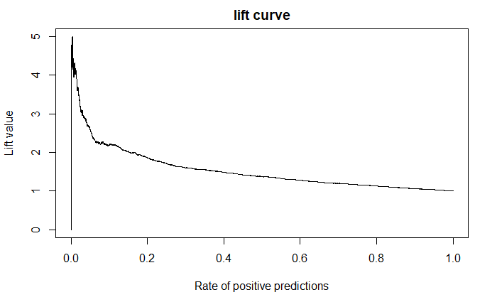

```r
glm_perf_test_lift <- performance(glm_pred_test,"lift","rpp")
plot(glm_perf_test_lift, main="lift curve", colorize=F)
```

Gini, K-S, Lift

```r
glm_validation = as.data.frame(c("Train", "Test"))
colnames(glm_validation) <- "Data"
glm_validation$Gini = c(Gini(glm_predict_train, abt_train$default_flg),
                        Gini(glm_predict_test, abt_test$default_flg))
glm_validation$KS = c(KS_Stat(glm_predict_train, abt_train$default_flg),
                      KS_Stat(glm_predict_test, abt_test$default_flg))
glm_validation$LiftAUC = c(LiftAUC(glm_predict_train, abt_train$default_flg),
                           LiftAUC(glm_predict_test, abt_test$default_flg))
glm_validation
```

| Data | Gini | KS | LiftAUC |
| --- | --- | --- | --- |
| Train | 0.3116955 | 22.89538 | 1.565191 |
| Test | 0.2908269 | 21.37436 | 1.537919 |

#### Дерево решений

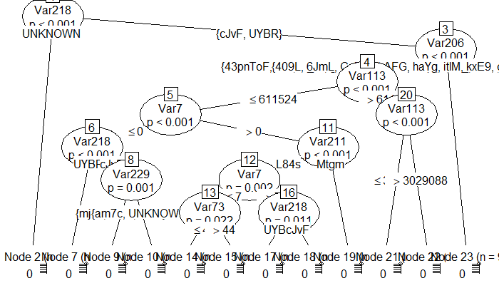

```r
tree <- ctree(default_flg ~ ., data = abt_train)
plot(tree)
```

```r
tree_predict_train <- predict(tree, type = 'response')
tree_predict_test <- predict(tree, newdata=abt_test, type = 'response')
tree_pred_test <- prediction(tree_predict_test, abt_test$default_flg)
```

```r
#TODO K-S ROC кривые Test
#perf_eva(abt_test$default_flg, tree_predict_test, title = "Test", groupnum = 20,
#         type = c("ks","roc"), show_plot = TRUE, seed = 186)$pic
```

Лифт Test

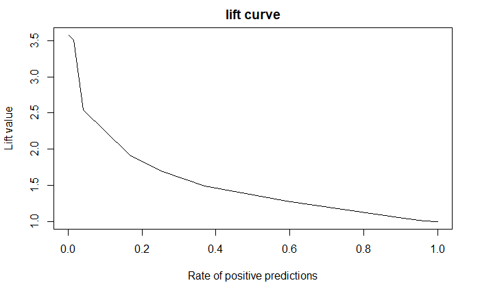

```r
tree_perf_test_lift <- performance(tree_pred_test,"lift","rpp")
plot(tree_perf_test_lift, main="lift curve", colorize=F)
```

Gini, KS, Lift

```r
tree_validation = as.data.frame(c("Train", "Test"))
colnames(tree_validation) <- "Data"
tree_validation$Gini = c(Gini(tree_predict_train, abt_train$default_flg),
                         Gini(tree_predict_test, abt_test$default_flg))
tree_validation$KS = c(KS_Stat(tree_predict_train, abt_train$default_flg),
                       KS_Stat(tree_predict_test, abt_test$default_flg))
tree_validation$LiftAUC = c(LiftAUC(tree_predict_train, abt_train$default_flg),
                            LiftAUC(tree_predict_test, abt_test$default_flg))
tree_validation
```

| Data | Gini | KS | LiftAUC |
| --- | --- | --- | --- |
| Train | 0.2901473 | 21.10297 | 1.598486 |
| Test | 0.2620094 | 19.45850 | 1.516752 |

#### XGBoost

Дополнительное преобразование данных создание разряженной матрицы для номинальных признаков (One-hot encoding)

```r
abt_xgb <- sparse.model.matrix(default_flg~.-1, data = abt_train)
output_xgb = abt_train[,"default_flg"] == 1
```

Построение модели XGBoost

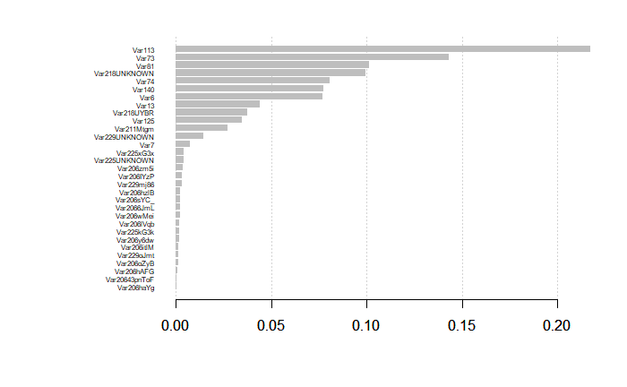

```r
xgb_model <- xgboost(data = abt_xgb, output_xgb, nrounds = 10, objective = "binary:logistic")
# Feature importance plot
xgb_importance <- xgb.importance(feature_names = colnames(abt_xgb), model = xgb_model)
xgb.plot.importance(importance_matrix = xgb_importance)
```

```r
abt_xgb_test = xgb.DMatrix(sparse.model.matrix(default_flg~.-1, data = abt_test))
xgb_predict_train <- predict(xgb_model, newdata=abt_xgb,type = 'response')
xgb_predict_test <- predict(xgb_model, newdata=abt_xgb_test, type = 'response')
xgb_pred_test <- prediction(xgb_predict_test, abt_test$default_flg)
```

K-S ROC кривые Test

```r
perf_eva(abt_test$default_flg, xgb_predict_test, title = "Test", groupnum = 20,
         type = c("ks","roc"), show_plot = TRUE, seed = 186)$pic
```

[output not shown]

[output not shown]

Лифт Test

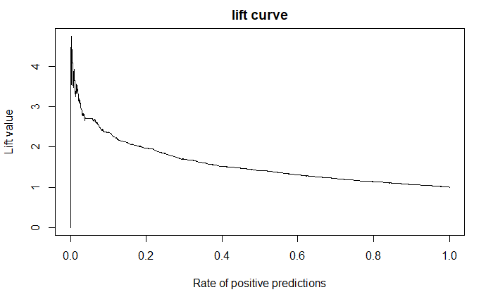

```r
xgb_perf_test_lift <- performance(xgb_pred_test,"lift","rpp")
plot(xgb_perf_test_lift, main="lift curve", colorize=F)
```

Gini, KS, Lift

```r
xgb_validation = as.data.frame(c("Train", "Test"))
colnames(xgb_validation) <- "Data"
xgb_validation$Gini = c(Gini(xgb_predict_train, abt_train$default_flg),
                        Gini(xgb_predict_test, abt_test$default_flg))
xgb_validation$KS = c(KS_Stat(xgb_predict_train, abt_train$default_flg),
                      KS_Stat(xgb_predict_test, abt_test$default_flg))
xgb_validation$LiftAUC = c(LiftAUC(xgb_predict_train, abt_train$default_flg),
                           LiftAUC(xgb_predict_test, abt_test$default_flg))
xgb_validation
```

| Data | Gini | KS | LiftAUC |
| --- | --- | --- | --- |
| Train | 0.4560890 | 31.94097 | 1.976186 |
| Test | 0.3224917 | 23.33792 | 1.581776 |

```r
glm_validation$Model = "Logistic Regression"
tree_validation$Model = "Decision Tree"
xgb_validation$Model = "XGBoost"
validation = rbind(glm_validation, tree_validation, xgb_validation)
validation$GiniIndex =  100*validation$Gini
```

Сравнение моделей по Gini

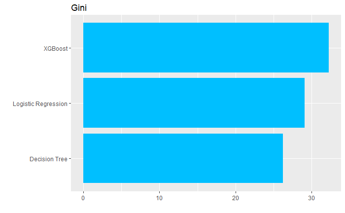

```r
validation %>% filter(Data=="Test") %>%
  ggplot(aes(x=Model)) +
  geom_bar(aes(y=GiniIndex), stat = "identity", position = "dodge", fill="deepskyblue1") +
  coord_flip() +
  xlab("") +
  ylab("") +
  ggtitle("Gini")
```

Сравнение моделей по Lift

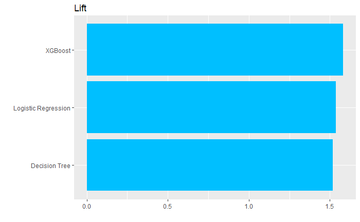

```r
validation %>% filter(Data=="Test") %>%
  ggplot(aes(x=Model)) +
  geom_bar(aes(y=LiftAUC), stat = "identity", position = "dodge", fill="deepskyblue1") +
  coord_flip() +
  xlab("") +
  ylab("") +
  ggtitle("Lift")
```

PSI

| variable | PSI |
| --- | --- |
| prob | Inf |

```
$`pic`
$`pic`$`prob`
```

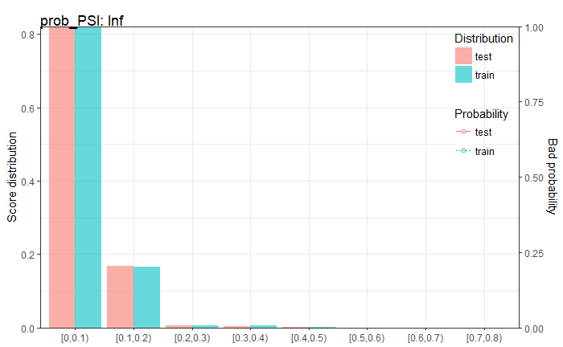

```r
score<-list(train=as.data.frame(glm_predict_train),
            test=as.data.frame(glm_predict_test))
colnames(score$train) <- "prob"
colnames(score$test) <- "prob"
perf_psi(score=score, x_limits = c(0,1), x_tick_break=0.1)
```